# novel-corona-virus-2019

# 1. Problem Statement

## 1.1 Background Information

The COVID-19 outbreak was first identified in December 2019 in Wuhan, China. The WHO declared the outbreak a Public Health Emergency of International Concern on 30 January 2020 and a pandemic on 11 March (Wikipedia).

## 1.2 Challenges at hand

After taking test samples it takes 2 days to declare the result that the person got infected or not. In the mean time he may spread the disease knowingly or unknowingly.

## 1.3 Current Scenario

India at the 2nd place after USA. In India now only social spread is happening and it is going to peak level. In other part of world except USA it is gone down.

## 1.4 Plan of Action

Organizations worldwide have been collecting data so that the government can monitor and learn from this pandemic.

## 1.5 End Result

The data set gives list of confirmed covid-19 cases. From this we do some statistical analysis and arrive to useful information.

# 2. Study Requirements

- **Create a clear bar chart that displays the latest number of COVID-19 cases of the top 10 countries.**
- **Visualize the confirmed cases worldwide from January to March.**
- **Visualize the confirmed cases of COVID-19 in China and the rest of the world from January to March.**

# 3. Analysis Process

1. We are going to analyze based on Country.
2. We are going to analyze based on Date.
3. We will take that data and then come up with a **Covid Analysis**.
4. Finally, we will come up with a **Result**.

# 4. Loading Packages and Libraries

Alright! lets begin our covid analysis by installing some packages and loading all the libraries.

```r
library(dplyr)
library(psych)
library(DataExplorer)
library(ggplot2)
```

# 5. Covid Analysis Process

**Covid Analysis** is the process of analyzing confirmed cases based on country and time. Understanding covid analysis allows Governments to be more efficient in controlling the spread.

## 5.1 Importing Data

Lets import our data first.

```r
dataset = read.csv("E:\Document\Freelancer\time_series_covid_19_confirmed.csv", header = TRUE)
```

```
Error: '\D' is an unrecognized escape in character string starting ""E:\D"
```

## 5.2 Reading Data

Lets have a complete view of our data.

Lets have a look at the head of the data.

|  | Province.State | Country.Region | Lat | Long | X1.22.20 | X1.23.20 | X1.24.20 | X1.25.20 | X1.26.20 | X1.27.20 | X1.28.20 | X1.29.20 | X1.30.20 | X1.31.20 | X2.1.20 | X2.2.20 | X2.3.20 | X2.4.20 | X2.5.20 | X2.6.20 | X2.7.20 | X2.8.20 | X2.9.20 | X2.10.20 | X2.11.20 | X2.12.20 | X2.13.20 | X2.14.20 | X2.15.20 | … |
| --- | --- | --- | --- | --- | --- | --- | --- | --- | --- | --- | --- | --- | --- | --- | --- | --- | --- | --- | --- | --- | --- | --- | --- | --- | --- | --- | --- | --- | --- | --- |
| 1 |  | Thailand | 15.0000 | 101.0000 | 2 | 3 | 5 | 7 | 8 | 8 | 14 | 14 | 14 | 19 | 19 | 19 | 19 | 25 | 25 | 25 | 25 | 32 | 32 | 32 | 33 | 33 | 33 | 33 | 33 | … |
| 2 |  | Japan | 36.0000 | 138.0000 | 2 | 1 | 2 | 2 | 4 | 4 | 7 | 7 | 11 | 15 | 20 | 20 | 20 | 22 | 22 | 45 | 25 | 25 | 26 | 26 | 26 | 28 | 28 | 29 | 43 | … |
| 3 |  | Singapore | 1.2833 | 103.8333 | 0 | 1 | 3 | 3 | 4 | 5 | 7 | 7 | 10 | 13 | 16 | 18 | 18 | 24 | 28 | 28 | 30 | 33 | 40 | 45 | 47 | 50 | 58 | 67 | 72 | … |
| 4 |  | Nepal | 28.1667 | 84.2500 | 0 | 0 | 0 | 1 | 1 | 1 | 1 | 1 | 1 | 1 | 1 | 1 | 1 | 1 | 1 | 1 | 1 | 1 | 1 | 1 | 1 | 1 | 1 | 1 | 1 | … |
| 5 |  | Malaysia | 2.5000 | 112.5000 | 0 | 0 | 0 | 3 | 4 | 4 | 4 | 7 | 8 | 8 | 8 | 8 | 8 | 10 | 12 | 12 | 12 | 16 | 16 | 18 | 18 | 18 | 19 | 19 | 22 | … |
| 6 | British Columbia | Canada | 49.2827 | -123.1207 | 0 | 0 | 0 | 0 | 0 | 0 | 1 | 1 | 1 | 1 | 1 | 1 | 1 | 1 | 2 | 2 | 4 | 4 | 4 | 4 | 4 | 4 | 4 | 4 | 4 | … |

**glimpse** gives you a better organized structure of the data.

```r
glimpse(dataset)
```

```
Rows: 501
Columns: 66
$ Province.State <chr> "", "", "", "", "", "British Columbia", "New So...
$ Country.Region <chr> "Thailand", "Japan", "Singapore", "Nepal", "Mal...
$ Lat            <dbl> 15.0000, 36.0000, 1.2833, 28.1667, 2.5000, 49.2...
$ Long           <dbl> 101.0000, 138.0000, 103.8333, 84.2500, 112.5000...
$ X1.22.20       <int> 2, 2, 0, 0, 0, 0, 0, 0, 0, 0, 0, 0, 0, 0, 0, 0,...
$ X1.23.20       <int> 3, 1, 1, 0, 0, 0, 0, 0, 0, 0, 0, 0, 0, 0, 0, 0,...
$ X1.24.20       <int> 5, 2, 3, 0, 0, 0, 0, 0, 0, 0, 0, 0, 0, 0, 0, 0,...
$ X1.25.20       <int> 7, 2, 3, 1, 3, 0, 0, 0, 0, 0, 0, 0, 0, 0, 0, 0,...
$ X1.26.20       <int> 8, 4, 4, 1, 4, 0, 3, 1, 0, 0, 0, 0, 0, 0, 0, 0,...
$ X1.27.20       <int> 8, 4, 5, 1, 4, 0, 4, 1, 0, 1, 1, 1, 0, 0, 0, 0,...
$ X1.28.20       <int> 14, 7, 7, 1, 4, 1, 4, 1, 0, 1, 1, 4, 0, 0, 0, 0...
$ X1.29.20       <int> 14, 7, 7, 1, 7, 1, 4, 1, 1, 1, 1, 4, 1, 4, 0, 0...
$ X1.30.20       <int> 14, 11, 10, 1, 8, 1, 4, 2, 3, 1, 1, 4, 1, 4, 1,...
```

[output cut: 53 more lines]

Using the **describe()** function, we can compute descriptive statistics for numerical data. The descriptive statistics help determine the distribution of numerical variables.

```r
describe(dataset)
```

[output not shown]

|  | vars | n | mean | sd | median | trimmed | mad | min | max | range | skew | kurtosis | se |
| --- | --- | --- | --- | --- | --- | --- | --- | --- | --- | --- | --- | --- | --- |
| Province.State* | 1 | 501 | NaN | NA | NA | NaN | NA | Inf | -Inf | -Inf | NA | NA | NA |
| Country.Region* | 2 | 501 | NaN | NA | NA | NaN | NA | Inf | -Inf | -Inf | NA | NA | NA |
| Lat | 3 | 501 | 30.29 | 19.87 | 37.25 | 33.20 | 10.00 | -41.45 | 72.00 | 113.45 | -1.44 | 2.04 | 0.89 |
| Long | 4 | 501 | -33.10 | 80.66 | -73.18 | -41.92 | 65.55 | -157.86 | 178.06 | 335.92 | 0.82 | -0.56 | 3.60 |
| X1.22.20 | 5 | 501 | 1.11 | 19.89 | 0.00 | 0.00 | 0.00 | 0.00 | 444.00 | 444.00 | 22.05 | 488.01 | 0.89 |
| X1.23.20 | 6 | 501 | 1.30 | 19.97 | 0.00 | 0.00 | 0.00 | 0.00 | 444.00 | 444.00 | 21.76 | 479.13 | 0.89 |
| X1.24.20 | 7 | 501 | 1.88 | 24.88 | 0.00 | 0.00 | 0.00 | 0.00 | 549.00 | 549.00 | 21.28 | 464.16 | 1.11 |
| X1.25.20 | 8 | 501 | 2.86 | 34.64 | 0.00 | 0.00 | 0.00 | 0.00 | 761.00 | 761.00 | 20.98 | 455.17 | 1.55 |
| X1.26.20 | 9 | 501 | 4.23 | 48.42 | 0.00 | 0.00 | 0.00 | 0.00 | 1058.00 | 1058.00 | 20.64 | 444.80 | 2.16 |
| X1.27.20 | 10 | 501 | 5.84 | 65.25 | 0.00 | 0.00 | 0.00 | 0.00 | 1423.00 | 1423.00 | 20.52 | 441.18 | 2.92 |

[output cut: 56 more lines]

## 5.3 Cleaning the Data

Now, lets do some data cleaning. For that, first we need to figure out the number of **missing values** in each column.

```r
numColumns = dim(dataset)[2]
vector_NAs = rep(0, numColumns)
for (i in 1:numColumns) {
  vector_NAs[i] = sum(is.na(dataset[,i]))
}
print("The missing values in each column:")
```

```
[1] "The missing values in each column:"
```

```r
print(vector_NAs)
```

```
 [1]   0   0   0   0   0   0   0   0   0   0   0   0   0   0   0   0   0
[18]   0   0   0   0   0   0   0   0   0   0   0   0   0   0   0   0   0
[35]   0   0   0   0   0   0   0   0   0   0   0   0   0   0   0   0   0
[52]   0   0   0   0   0   0   0   0   0   0   0   0   0   0 192
```

It appears that column **66** has maximum number of missing values which accumulates approximately 40 percent of the data points.

**192** missing values are really high in number. Therefore, it is essential to delete this column as it doesn’t contribute much to our analysis.

```r
dataset = dataset[,-c(66)]
print(dim(dataset))
```

```
[1] 501  65
```

## 5.4 Add a Column

```r
View(dataset_numeric)
print(rowSums(dataset_numeric))
```

```
  [1]    4035   16564    6560      59    8891    2343    3148    1475
  [9]    1461     372     497  136101    3871    1965    2252    2373
 [17]  438821   15544  157432     539   17923    2350      55    1738
 [25]    2224     543     249    3755    2272     991    1175   39168
 [33]   17715    5579    3356    5596     498    4549     477   18392
 [41]    2524    2331    1522     547    3431     412    1126     289
 [49]     109     518    4176    2898      93    4920    2286     414
 [57]     886     534    2595    6707     423     116     729     546
 [65]    2403     347    1013    2702     474     219     681      21
 [73]     187    3047     380     551    2993    1265      20     142
 [81]     963     671    1658    1003    1034      55     463     209
 [89]     923     153     147     123    2649    1102     978     624
 [97]     524     653   12541   48745    8731    3265    1259     349
[105]    2558    2385    3473    5848     806    2463    3509    1959
[113]     411     984    1125     790    1599     940     516     648
```

[output cut: 48 more lines]

## 5.5 Analyze Data

Lets use the **barplot** function to do **bivariate analysis** of some variables.

### 5.5.1 Which state is highly affected?

Lets begin with a variable **State**.

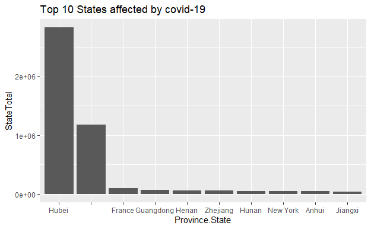

### 5.5.2 Which country is highly affected?

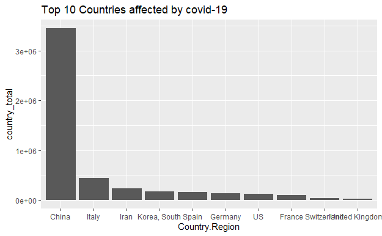

```r
dataset %>% group_by(Country.Region) %>% summarise(country_total = sum(StateTotal)) %>% top_n(10, country_total) %>%
  ggplot(aes(reorder(Country.Region, -country_total), country_total))+
  geom_col() +
  labs(x="Country.Region", title="Top 10 Countries affected by covid-19")
```

### 5.5.3 World wide confirmed cases?

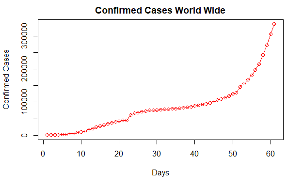

The above line chart shows that confirmed cases increased world wide between 22nd January 2020 to 22nd March 2020.

In first 20 days, the maximum of confirmed cases world wide on a single day around **40,000**

In next 30 days, the maximum of confirmed cases world wide on a single day reaches to **1,20,000**

In next 10 days, the maximum of confirmed cases world wide on a single day reaches to **3,20,000**

### 5.5.4 Confirmed cases between China and World?

```r
vector_NAs_china = rep(0, 65)
vector_NAs_world = rep(0, 65)
nRows = dim(dataset)[1]
sum_china=0
sum_world=0
for (i in 5:65) {
  for (j in 1:nRows) {
    if (dataset[j,2]=='China')
      sum_china = sum_china + dataset[j,i]
    else
      sum_world = sum_world + dataset[j,i]
  }
  vector_NAs_china[i] = sum_china
  vector_NAs_world[i] = sum_world
  sum_china=0
  sum_world=0
}
```

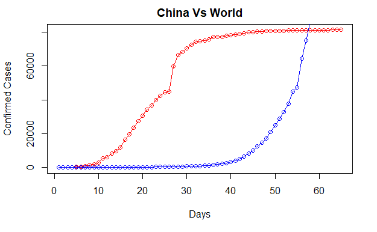

The above line chart shows the comparison of confirmed cases increment between China and world in the time period 22nd January 2020 to 22nd March 2020.

The Red line shows **China**

The Blue line shows **World**

In first 10 days, there is no much difference between china and rest of the world.

In next 30 days, china reached its peak and become stable of confirmed cases, whereas this time only confirmed cases started growing in rest of the world.

In next 20 days, the confirmed cases increases 1000 multiples world wide except china. In china, the cases are not increasing and it became stable.

After 50th day, the confirmed cases increases vertically in the graph, At the same time **WHO** announces **pandemic** on 11th March.

### 5.5.5 Confirmed cases in India?

```r
vector_NAs_india = rep(0, 65)
sum_india=0
for (i in 5:65) {
  for (j in 1:nRows) {
    if (dataset[j,2]=='India')
      sum_india = sum_india + dataset[j,i]
  }
  vector_NAs_india[i] = sum_india
  sum_india=0
}
```

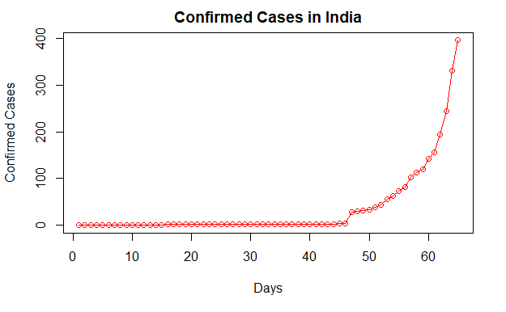

The above chart shows increment of confirmed cases in **India**, When world wide cases increases in 1000 multiples here the cases increases in 10 multiples only.

Till **55th day** the increment of confirmed cases less than **100** only.

In India, the increment is started slowly, but now we are at the 2nd place after USA.

# 6. Conclusion

So, at last we are coming to the conclusion based on our analysis that

Initially **China** got affected much and it started spreading world wide.

When **USA**, **European** countries got affected 1000 multiples, **India** was affected in 10 multiples only. This time **China** became stable.

Now in **India** the cases are increasing 1000 multiples.

People need to be more **social conscious** in order to avoid increase.

Till to find **vaccine** the confirmed cases can’t be zero.